# Обработка текста на Python / NLP with Python

Примерно то, что требуется в задании, продемонстрировано в статье на хабре по [ссылке](https://habr.com/ru/post/517410/).

Продемонстрируем некоторые отдельные вопросы, которые возможно возникнут при выполнении задания.

## Установка зависимостей в колабе

Необходимо использовать магические ячейки и установить некоторые библиотеки, которых в базовом наборе библиотек колаба, нет.

```python
%%sh

pip install yargy # для обработки текста
pip install natasha # для обработки текста
pip install wordcloud # для создания изображения с облаком тегов
```

## Парсинг и обработка информации со страниц сайта

Можно использовать механизм, используемый в прошлой ЛР (BeautifulSoup) или что-то другое.

Предлагается использовать регулярные выражения, поскольку все новости на сайте ведут на подраздел `/news/*`

Извлекаем ссылки на конкретные новости и открываем каждую страницу аналогичным образом получаем текст новости полностью.

Не забыть выполнить предварительную очистку и токенизацию текста по словам. После очистки текста требуется положить его в отдельный текстовый файл или сохранить в строковую переменную. В конце — склеить весь текст в единый текстовый файл.

Затем, используя [библиотеку natasha](https://natasha.github.io/ner/) извлекаем имена упоминаемых в тексте людей и добавляем их в json-файл. Далее, для имён требуется сериализовать данные из json-файла, убрав имена и оставив только фамилии. После этого сделать из фамилий текст и визуализировать информацию о статистики встречаемости в виде облака тегов. Аналогично, сделать облако тегов для ключевых понятий.

```python
import re
from urllib.request import urlopen
from bs4 import BeautifulSoup
html = urlopen('https://www.herzen.spb.ru/main/news/')
bs = BeautifulSoup(html, "html.parser")
# news3.jpg
div = bs.find('div', {'class':'news_container'})

print(div)
# news_p_array = image.parent.parent.children
```

```
<div class="news_container" style="padding:0 0 20 0"><b>11 октября 2022</b><br/><span class="news_header"><p><strong>Проект «Александрова дорога»: <a href="https://www.youtube.com/watch?v=WXz56pOSdyo">1 СЕРИЯ. ПЕРЕСЛАВЛЬ-ЗАЛЕССКИЙ. НАЧАЛО ПУТИ</a></strong></p>
</span></div>
```

## Построение изображения с облаком тегов на Python

Для примера визуализируем наиболее часто встречаемые слова из текста А. С. Пушкина "Метель".

```python
%%capture
!wget https://raw.githubusercontent.com/Metafiz/nlp-course-20/master/pushkin-metel.txt
```

```python
%matplotlib inline
```

```
(-0.5, 399.5, 199.5, -0.5)
```

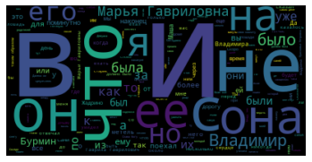

```python
from wordcloud import WordCloud
import matplotlib.pyplot as plt

f = open('pushkin-metel.txt', "r", encoding="utf-8")
text = f.read()
# wordcloud = WordCloud().generate(text)

text2 = """
Lorem ipsum dolor sit amet,
Lorem ipsum dolor
Lorem ipsum
Lorem


    """
wordcloud = WordCloud().generate(text)
plt.imshow(wordcloud, interpolation='bilinear')
plt.axis("off")
```

Получилось плохо, потому что мы не предобработали текст (в частности: не убрали стоп-слова, не провели лемматизацию текста, не сегментировали текст).

```python
%%sh

pip install natasha # для обработки текста
```

```python
%%capture
!wget https://raw.githubusercontent.com/Metafiz/nlp-course-20/master/pushkin-metel.txt
```

```python
from natasha import (
    Segmenter,
    MorphVocab,

    NewsEmbedding,
    NewsMorphTagger,
    NewsSyntaxParser,
    NewsNERTagger,

    PER,
    NamesExtractor,

    Doc
)

segmenter = Segmenter()
morph_vocab = MorphVocab()

emb = NewsEmbedding()
morph_tagger = NewsMorphTagger(emb)
syntax_parser = NewsSyntaxParser(emb)
ner_tagger = NewsNERTagger(emb)

names_extractor = NamesExtractor(morph_vocab)

f = open('pushkin-metel.txt', "r", encoding="utf-8")
text = f.read()


doc = Doc(text)
doc.segment(segmenter)
doc.tag_morph(morph_tagger)
doc.parse_syntax(syntax_parser)


doc.tag_ner(ner_tagger)

for span in doc.spans:
    span.normalize(morph_vocab)

# print({_.text: _.normal for _ in doc.spans})


for span in doc.spans:
    if span.type == PER:
        span.extract_fact(names_extractor)

{_.normal: _.fact.as_dict for _ in doc.spans if _.fact}
```

```
{'Ненарадове': {'last': 'Ненарадове'},
 'Гаврила Гаврилович Р**': {'first': 'Гаврила', 'last': 'Гаврилович'},
 'Прасковьей Петровною': {'first': 'Прасковьей', 'last': 'Петровною'},
 'Марью Гавриловну': {'first': 'Марью', 'last': 'Гавриловну'},
 'Марья Гавриловна': {'first': 'Марья', 'last': 'Гавриловна'},
 'Марьи Гавриловны': {'first': 'Марьи', 'last': 'Гавриловны'},
 'Владимир Николаевич': {'first': 'Владимир', 'last': 'Николаевич'},
 'Владимир': {'first': 'Владимир'},
 'Маша': {'first': 'Маша'},
 'Пришед': {'first': 'Пришед'},
 'Терешки-кучера': {'last': 'Терешки'},
 'Дравин': {'first': 'Дравин'},
 'Шмит': {'last': 'Шмит'},
 'Терешку': {'last': 'Терешку'},
 'Жадрина': {'first': 'Жадрина'},
 'Жадрин': {'first': 'Жадрин'},
 'Али': {'first': 'Али'},
 'Гаврила Гаврилович': {'first': 'Гаврила', 'last': 'Гаврилович'},
 'Прасковья Петровна': {'first': 'Прасковья', 'last': 'Петровна'},
 'Терешка-кучер': {'last': 'Терешка'},
 'Артемизы': {'first': 'Артемизы'},
 'Н. Изоар': {'first': 'Н', 'last': 'Изоар'},
 'А. Грибоедов': {'first': 'А', 'last': 'Грибоедов'},
 'Чацкий': {'last': 'Чацкий'},
 'Бурмин': {'last': 'Бурмин'},
 'Георгий': {'first': 'Георгий'},
 'Петрарка': {'last': 'Петрарка'},
 'Марьей Гавриловной': {'first': 'Марьей', 'last': 'Гавриловной'},
 'Марьи Гавриловна': {'first': 'Марьи', 'last': 'Гавриловна'},
 'Марье Гавриловне': {'first': 'Марье', 'last': 'Гавриловне'},
 'Ж.-Ж. Руссо': {'last': 'Ж'},
 'Юлия': {'first': 'Юлия'}}
```

Семестр7-ЛР6

```python
%%sh

pip install yargy # для обработки текста
pip install natasha # для обработки текста
pip install wordcloud # для создания изображения с облаком тегов
```

```
  Attempting uninstall: intervaltree
    Found existing installation: intervaltree 2.1.0
    Uninstalling intervaltree-2.1.0:
      Successfully uninstalled intervaltree-2.1.0
```

```python
HERZEN_MAIN = 'https://www.herzen.spb.ru'
import re
from urllib.request import urlopen
from bs4 import BeautifulSoup
html = urlopen('https://www.herzen.spb.ru/main/news/')
bs = BeautifulSoup(html, "html.parser")
# news3.jpg
blockwh = bs.find('td', {'class':'blockwh'}).find_all('a', {'class':'news_header_link'}, limit=30) # 30 = the amount of news on one page.

# print(blockwh)
# news_p_array = image.parent.parent.children
links_list = []
for el in blockwh:
  links_list.append(HERZEN_MAIN + el['href'])
print(links_list)
```

```
['https://www.herzen.spb.ru/news/17-10-2022_2/', 'https://www.herzen.spb.ru/news/17-10-2022_1/', 'https://www.herzen.spb.ru/news/17-10-2022/', 'https://www.herzen.spb.ru/news/16-10-2022/', 'https://www.herzen.spb.ru/news/14-10-2022_2/', 'https://www.herzen.spb.ru/news/14-10-2022_1/', 'https://www.he…
```

```python
complete_news_page_list = []
for el in links_list:
  temp_html = urlopen(el)
  temp_bs = BeautifulSoup(temp_html, "html.parser")
  another_blockwh = temp_bs.find('td', {'class':'blockwh'})
  another_blockwh_title = another_blockwh.h1.get_text()
  another_blockwh_contentblock = another_blockwh.find_all('p')
  another_blockwh_content_stripped = another_blockwh_title
  for el in another_blockwh_contentblock:
    stripped = el.strings
    for inner_el in stripped:
      another_blockwh_content_stripped += inner_el
    # print(inner_el)
  complete_news_page_list.append(another_blockwh_content_stripped)
# print(another_blockwh_content_stripped[0])
```

```python
print(complete_news_page_list[0])
```

```
Актуальные вопросы в повестке очередного заседания ректората «Ковид-19» снизил свою активность, но окончательно сдавать свои позиции не торопится. Меры по санитарно-эпидемиологической защите сотрудников и студентов были в центре внимания заседания ректората, которое провел сегодня, 17 октября, в дис…
```

```python
from natasha import (
    Segmenter,
    MorphVocab,

    NewsEmbedding,
    NewsMorphTagger,
    NewsSyntaxParser,
    NewsNERTagger,

    PER,
    NamesExtractor,

    Doc
)

segmenter = Segmenter()
morph_vocab = MorphVocab()

emb = NewsEmbedding()
morph_tagger = NewsMorphTagger(emb)
syntax_parser = NewsSyntaxParser(emb)
ner_tagger = NewsNERTagger(emb)

names_extractor = NamesExtractor(morph_vocab)
```

```python
%matplotlib inline
from wordcloud import WordCloud
import matplotlib.pyplot as plt
```

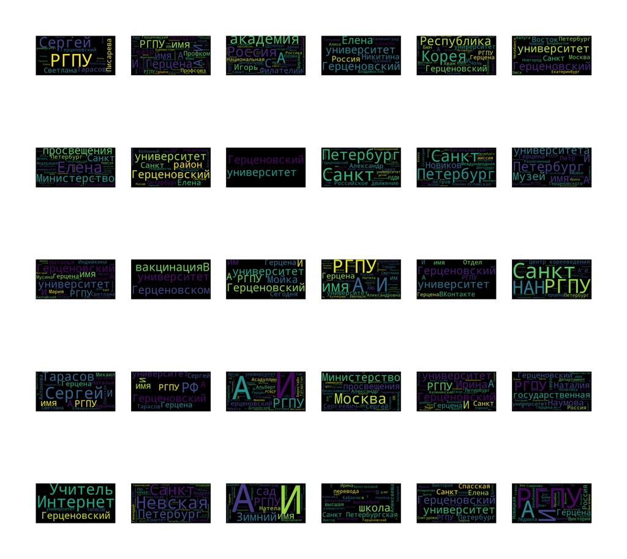

```python
plt.figure(figsize=(2, 2), dpi=1000)
i = 1
full_wordcloud = ''
for el in complete_news_page_list:
  doc = Doc(el)
  doc.segment(segmenter)
  doc.tag_morph(morph_tagger)
  doc.parse_syntax(syntax_parser)
  doc.tag_ner(ner_tagger)
  for token in doc.tokens:
    token.lemmatize(morph_vocab)
  for span in doc.spans:
    span.normalize(morph_vocab)
  words_for_cloud_str = ''
  for span in doc.spans:
    words_for_cloud_str += span.normal + ' '

  full_wordcloud += words_for_cloud_str + ' '
  wordcloud = WordCloud().generate(words_for_cloud_str)
  plt.subplot(5, 6, i)
  i += 1
  plt.imshow(wordcloud, interpolation='bilinear')
  plt.axis("off")
```

```
(-0.5, 399.5, 199.5, -0.5)
```

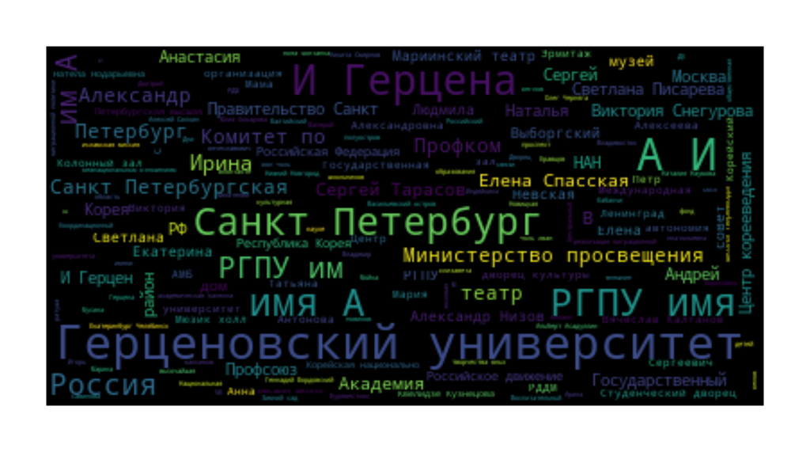

```python
plt.figure(figsize=(2, 2), dpi=2000)
full_wordcloud_cloud = WordCloud().generate(full_wordcloud)
plt.imshow(full_wordcloud_cloud, interpolation='bilinear')
plt.axis("off")
```